# abmR: An R Package for Agent-based Model Analysis of Large-scale Movements Across Taxa

Benjamin Gochanour, Javi Fernandez Lopez, Andrea Contina

2020-10-26

```r
library(lemon)
library(knitr)
```

# I. Getting Started

## Installation

To use `abmR`, you must first install it from Github using `devtools` and load the library:

```r
#devtools: install_github("bgoch5/move-model",subdir="abmr")
library(abmr,quietly=TRUE,warn.conflicts=FALSE)
```

While this package is still in development, it will be updated frequently, so please be sure to re-install frequently.

For `abmR` to work, you will need updated versions of the following packages: `geosphere`, `ggplot2`, `raster`, `rgdal`, `rnaturalearth`, `rnaturalearthdata`, `sp`, `swfscMisc`, `table1`.

## Requirements for Environmental Data Rasters and Species objects

The modeling functions discussed below require several input objects to work, which we will discuss here.

1. A shapefile that represents the boundaries for your movements.

```r
library(rgdal) #For reading in shapefile
NOAM=readOGR(layer="NOAM",dsn=".")
```

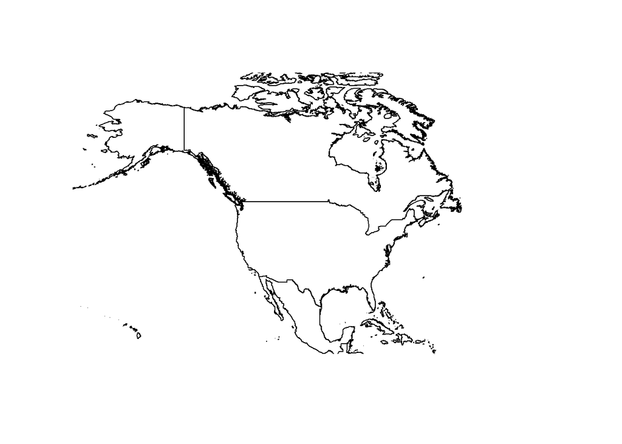

```r
plot(NOAM,xlim=c(-130,-60),ylim=c(18,75))
```

2. A environmental NDVI raster stack. We are currently working on how to attach an example raster to the package, but you can read yours in like this. Here, we plot just the first four layers.

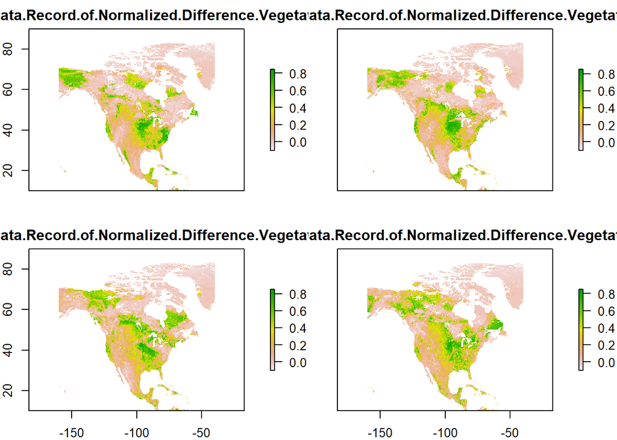

```r
library(raster)
ndvi_raster=stack("C:\\Users\\BGOCHANOUR\\Documents\\GitHub\\move-model\\Input_Data\\NDVI_2013.gri")
plot(ndvi_raster[[1:4]])
```

3. A species object to describe the species that you will model.

```r
species <- setClass("species", slots=c(x="numeric", y="numeric",mass="numeric",
                                       wing="numeric"))
ocwa.pop <- species(x=-112.24, y =52.24, mass=15, wing=19)
```

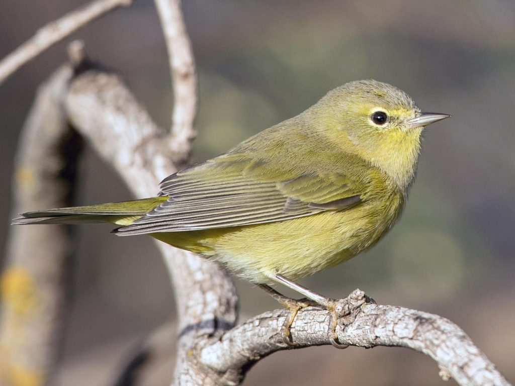

```r
# Small fig.width
include_graphics("OCWA.jpg")
```

# II. Running Agent-based models

Both `moveSIM` and `energySIM` will output two things: (1) a dataframe of results and (2) a summary table of input parameters

## `moveSIM`

```r
moveSIM_results=moveSIM(replicates=1,days=27,env_rast=ndvi_raster, search_radius=375,
  sigma=.4, dest_x=-100, dest_y=25, mot_x=1, mot_y=1,modeled_species=N_pop,
  my_shapefile=NOAM,optimum=.5,direction="S",write_results=TRUE,single_rast=FALSE)
```

```
#> [1] "Agent died"
```

```r
head(moveSIM_results$results,30)
```

| lon | lat | day | agent_id | distance |
| --- | --- | --- | --- | --- |
| -112.240 | 52.240 | 1 | Agent_1 | NA |
| -106.475 | 49.475 | 2 | Agent_1 | 508.52157 |
| -99.225 | 47.725 | 3 | Agent_1 | 567.88096 |
| -99.425 | 40.825 | 4 | Agent_1 | 768.26907 |
| -105.475 | 36.425 | 5 | Agent_1 | 718.50825 |
| -105.725 | 33.325 | 6 | Agent_1 | 345.84441 |
| -99.975 | 29.725 | 7 | Agent_1 | 676.77377 |
| -100.175 | 25.125 | 8 | Agent_1 | 512.45044 |
| -100.025 | 25.675 | 9 | Agent_1 | 63.05638 |
| -99.875 | 24.875 | 10 | Agent_1 | 90.32654 |
| -99.625 | 25.275 | 11 | Agent_1 | 51.16750 |
| -100.325 | 24.725 | 12 | Agent_1 | 93.46708 |
| -99.975 | 24.775 | 13 | Agent_1 | 35.81801 |
| -99.825 | 25.475 | 14 | Agent_1 | 79.37659 |
| -100.025 | 25.125 | 15 | Agent_1 | 43.85401 |
| -100.125 | 25.225 | 16 | Agent_1 | 15.01389 |
| -99.825 | 25.225 | 17 | Agent_1 | 30.21125 |
| -100.575 | 25.025 | 18 | Agent_1 | 78.80054 |
| -99.125 | 25.225 | 19 | Agent_1 | 147.82628 |
| -99.975 | 24.925 | 20 | Agent_1 | 91.98032 |
| -100.675 | 24.775 | 21 | Agent_1 | 72.65354 |
| -100.475 | 24.825 | 22 | Agent_1 | 20.96309 |
| NA | NA | 23 | Agent_1 | NA |
| NA | NA | 24 | Agent_1 | NA |
| NA | NA | 25 | Agent_1 | NA |
| NA | NA | 26 | Agent_1 | NA |
| NA | NA | 27 | Agent_1 | NA |

```r
moveSIM_results$run_params
```

| replicates | days | env_raster | search_radius | sigma | dest_x | dest_y | mot_x | mot_y | modeled_species | optimum | direction | write_results | single_rast | missing_pct |
| --- | --- | --- | --- | --- | --- | --- | --- | --- | --- | --- | --- | --- | --- | --- |
| 1 | 27 | env_raster | 375 | 0.4 | -100 | 25 | 1 | 1 | N_pop | 0.5 | S | TRUE | FALSE | 18.51852 |

## `energySIM`

```r
energySIM_results=energySIM(replicates=1,days=27,env_rast=ndvi_raster, search_radius=375,
                  sigma=.4, dest_x=-100, dest_y=25, mot_x=1, mot_y=1,
                  modeled_species=N_pop, my_shapefile=NOAM,
                  optimum_lo=.4,optimum_hi=.6,init_energy=100,
                  direction="S",write_results=TRUE,single_rast=FALSE)
```

```
#> [1] "Agent died"
```

```r
head(energySIM_results$results,30)
```

| lon | lat | energy | day | agent_id | distance | delta_energy |
| --- | --- | --- | --- | --- | --- | --- |
| -112.240 | 52.240 | 100 | 1 | Agent_1 | NA | NA |
| -114.975 | 44.875 | 90 | 2 | Agent_1 | 844.10587 | -10 |
| -111.225 | 39.925 | 70 | 3 | Agent_1 | 631.22229 | -20 |
| -107.775 | 38.375 | 60 | 4 | Agent_1 | 344.16309 | -10 |
| -107.825 | 37.925 | 40 | 5 | Agent_1 | 50.28463 | -20 |
| -104.975 | 37.025 | 20 | 6 | Agent_1 | 270.96913 | -20 |
| -104.925 | 36.875 | 0 | 7 | Agent_1 | 17.28023 | -20 |
| NA | NA | NA | 8 | Agent_1 | NA | NA |
| NA | NA | NA | 9 | Agent_1 | NA | NA |
| NA | NA | NA | 10 | Agent_1 | NA | NA |
| NA | NA | NA | 11 | Agent_1 | NA | NA |
| NA | NA | NA | 12 | Agent_1 | NA | NA |
| NA | NA | NA | 13 | Agent_1 | NA | NA |
| NA | NA | NA | 14 | Agent_1 | NA | NA |
| NA | NA | NA | 15 | Agent_1 | NA | NA |
| NA | NA | NA | 16 | Agent_1 | NA | NA |
| NA | NA | NA | 17 | Agent_1 | NA | NA |
| NA | NA | NA | 18 | Agent_1 | NA | NA |
| NA | NA | NA | 19 | Agent_1 | NA | NA |
| NA | NA | NA | 20 | Agent_1 | NA | NA |
| NA | NA | NA | 21 | Agent_1 | NA | NA |
| NA | NA | NA | 22 | Agent_1 | NA | NA |
| NA | NA | NA | 23 | Agent_1 | NA | NA |
| NA | NA | NA | 24 | Agent_1 | NA | NA |
| NA | NA | NA | 25 | Agent_1 | NA | NA |
| NA | NA | NA | 26 | Agent_1 | NA | NA |
| NA | NA | NA | 27 | Agent_1 | NA | NA |

```r
energySIM_results$run_params
```

| replicates | days | env_raster | search_radius | sigma | dest_x | dest_y | mot_x | mot_y | modeled_species | optimum_lo | optimum_hi | direction | write_results | single_rast | missing_pct | mortality_pct |
| --- | --- | --- | --- | --- | --- | --- | --- | --- | --- | --- | --- | --- | --- | --- | --- | --- |
| 1 | 27 | env_raster | 375 | 0.4 | -100 | 25 | 1 | 1 | N_pop | 0.4 | 0.6 | S | TRUE | FALSE | 74.07407 | 100 |

# III. Visualizing Results

The output from `moveSIM` and `energySIM` are simple dataframes, so one may easily visualize their results using custom codes. However, we have provided the following functions that include a set of default plots that you may find useful.

## `moveVIZ`

One may want a basic plot of each agent’s movement, as compared to a straight-line trajectory between the start and target endpoint. This can be obtained by

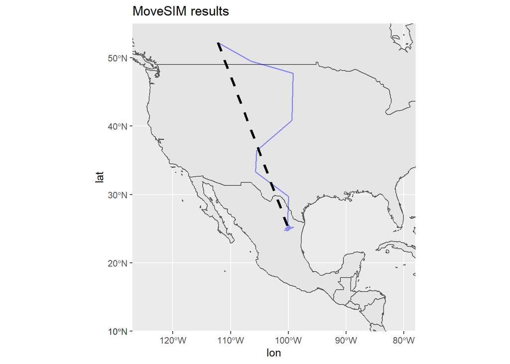

```r
moveVIZ(moveSIM_results,title="MoveSIM results")
```

## `energyVIZ`

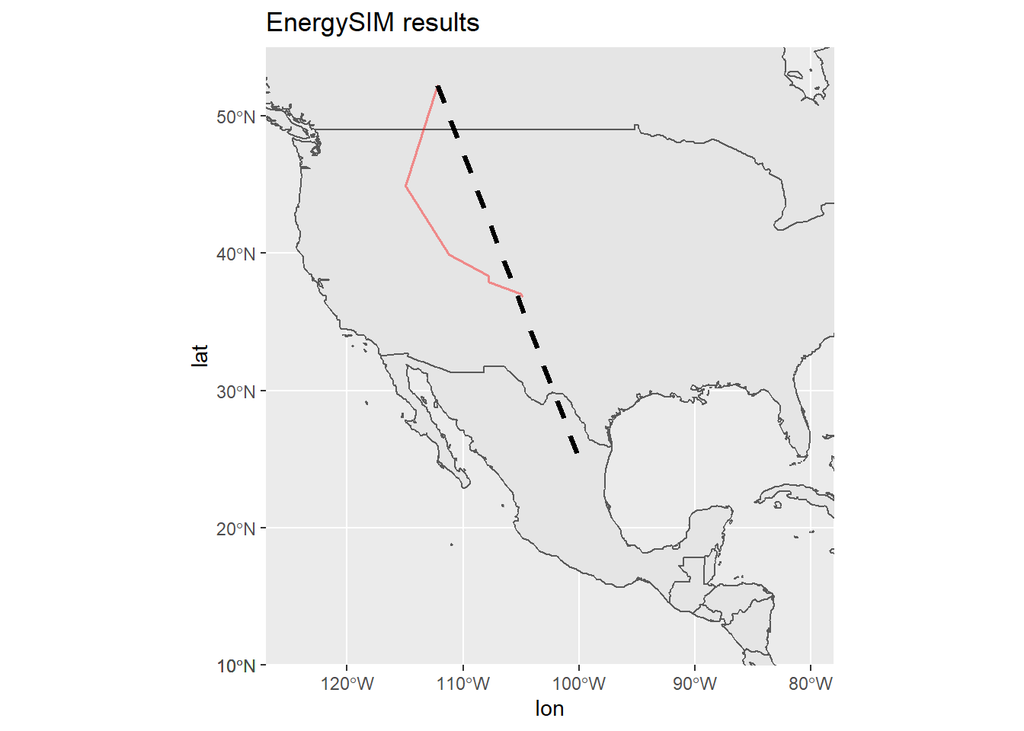

```r
energyVIZ(energySIM_results,title="EnergySIM results",type="plot")
```

One may also want to create a table to summarize energy, day, and distance, stratified by energy gain/loss amount. This can be obtained by setting the `type` argument to “table”.

```r
energyVIZ(energySIM_results,title="EnergySIM results",type="table")
```

|  | -20 (N=4) | -10 (N=2) | Overall (N=27) |
| --- | --- | --- | --- |
| energy |  |  |  |
| Mean (SD) | 32.5 (29.9) | 75.0 (21.2) | 54.3 (36.4) |
| Median [Min, Max] | 30.0 [0, 70.0] | 75.0 [60.0, 90.0] | 60.0 [0, 100] |
| Missing | 0 (0%) | 0 (0%) | 20 (74.1%) |
| day |  |  |  |
| Mean (SD) | 5.25 (1.71) | 3.00 (1.41) | 14.0 (7.94) |
| Median [Min, Max] | 5.50 [3.00, 7.00] | 3.00 [2.00, 4.00] | 14.0 [1.00, 27.0] |
| distance |  |  |  |
| Mean (SD) | 242 (283) | 594 (354) | 360 (325) |
| Median [Min, Max] | 161 [17.3, 631] | 594 [344, 844] | 308 [17.3, 844] |
| Missing | 0 (0%) | 0 (0%) | 21 (77.8%) |

# IV. Getting Help

Need help? Have suggestions to make `abmR` better? If so, please open an issue or pull request on Github (https://github.com/bgoch5/move-model/tree/master/abmr), or drop me an email at ben.gochanour@ou.edu.